# Water_analysis

Elena Suranova

2025-03-18

# Study of Water Quality by Hardness and pH Parameters

## In this study, I will use the cleaned and prepared data from the first part of the project.

```r
stations_clean <- readRDS("stations_clean.RDS")
period_of_record_clean <- readRDS("period_of_record_clean.RDS")
lab_results_clean <- readRDS("lab_results_clean.RDS")
field_results_clean <- readRDS("field_results_clean.RDS")
```

## Data Selection for Study

Data related to water hardness and pH from the lab_results_clean and field_results_clean tables.

```r
# Unique parameters in lab_results_clean
unique_lab_parameters <- unique(lab_results_clean$parameter)
cat("Unique parameters in lab_results_clean:\n")
```

```
## Unique parameters in lab_results_clean:
```

```r
print(unique_lab_parameters)
```

```
##   [1] "Conductance"
##   [2] "Dissolved Boron"
##   [3] "Dissolved Calcium"
##   [4] "Dissolved Chloride"
##   [5] "Dissolved Magnesium"
##   [6] "Dissolved Sodium"
##   [7] "Total Alkalinity"
##   [8] "Total Hardness"
##   [9] "pH"
##  [10] "Dissolved Hardness"
##  [11] "Dissolved Potassium"
##  [12] "Dissolved Sulfate"
##  [13] "Total Dissolved Solids"
##  [14] "Dissolved Nitrate"
##  [15] "Dissolved Fluoride"
```

[output cut: 251 more lines]

For the analysis of water hardness, the following parameters can be used:

Dissolved Calcium: Calcium is a major component affecting water hardness. High levels of calcium may indicate hard water. Dissolved Magnesium: Magnesium, like calcium, is a key element determining water hardness. Total Hardness: A direct measure of water hardness, accounting for calcium and magnesium concentrations. For the study, I will use the general parameter Total Hardness from the lab_results_clean table.

```r
# Unique parameters in field_results_clean
unique_field_parameters <- unique(field_results_clean$parameter)
cat("\nUnique parameters in field_results_clean:\n")
```

```
##
## Unique parameters in field_results_clean:
```

```r
print(unique_field_parameters)
```

```
##  [1] DissolvedOxygen
##  [2] ElectricalConductance
##  [3] WaterTemperature
##  [4] pH
##  [5] Flow, channel
##  [6] Gauge Height
##  [7] PhenolphthaleinAlkalinity
##  [8] SpecificConductance
##  [9] Turbidity
## [10] Secchi Depth
## [11] Chlorophyll Volume
## [12] Water Depth at Station
## [13] Conductance
## [14] AirTemperature
## [15] Percent Cloud Cover
```

[output cut: 37 more lines]

From the field water analysis results table, I will use the Conductance parameter because water conductivity can be an indirect indicator of hardness, as it depends on the concentration of dissolved ions, including calcium and magnesium.

# Study

Since I will only consider two parameters, I believe that using temporary tables will simplify the analysis.

```r
library(dplyr)
# Temporary table for pH
ph_lab <- lab_results_clean %>% filter(parameter == "pH")
ph_field <- field_results_clean %>% filter(parameter == "pH")

# Temporary table for hardness
hardness_lab <- lab_results_clean %>% filter(parameter == "Total Hardness")
hardness_field <- field_results_clean %>% filter(parameter == "Conductance")
```

## Data Distribution Analysis

Analysis of pH distribution:

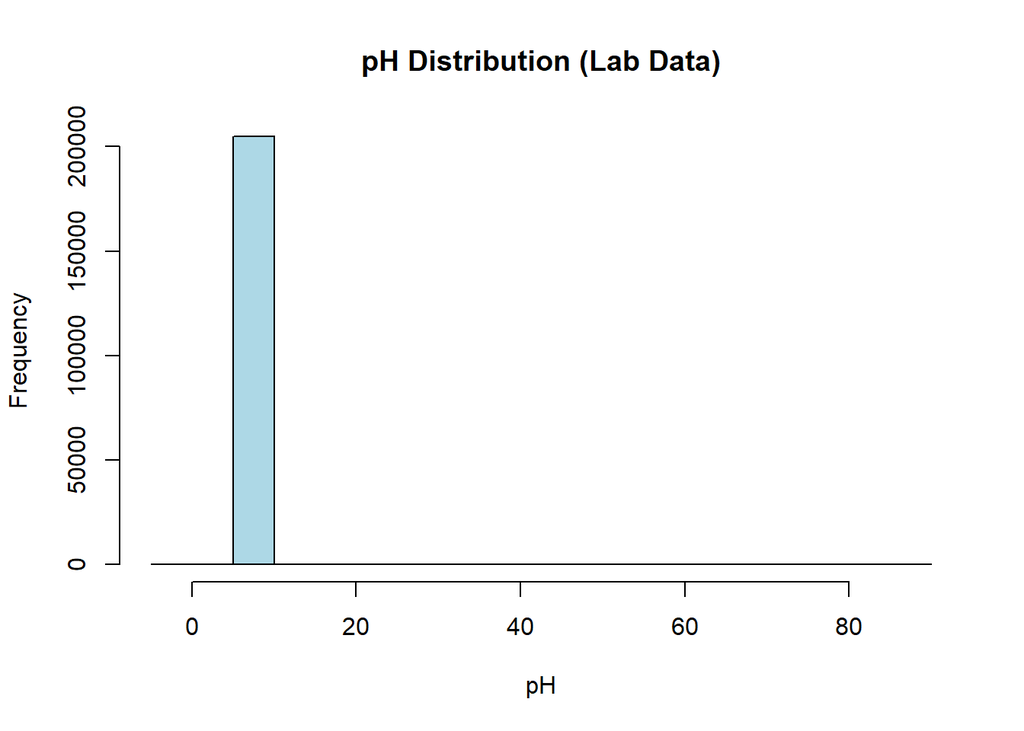

```r
# Histogram for pH (lab data)
hist(ph_lab$result, main = "pH Distribution (Lab Data)", xlab = "pH", col = "lightblue", breaks = 30)
```

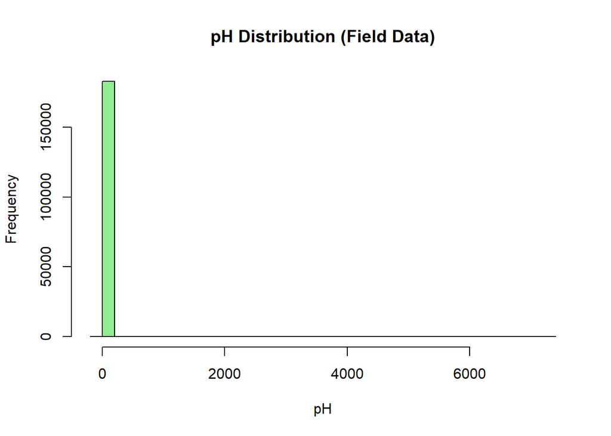

```r
# Histogram for pH (field data)
hist(ph_field$fdr_result, main = "pH Distribution (Field Data)", xlab = "pH", col = "lightgreen", breaks = 30)
```

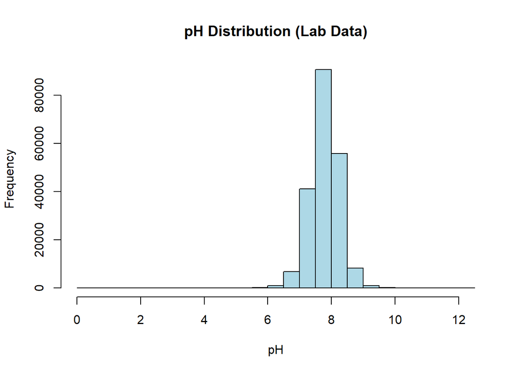

```r
# Filtering anomalous pH values
ph_lab_clean <- ph_lab %>% filter(result >= 0 & result <= 14)
ph_field_clean <- ph_field %>% filter(fdr_result >= 0 & fdr_result <= 14)

# Histogram for pH (lab data)
hist(ph_lab_clean$result, main = "pH Distribution (Lab Data)", xlab = "pH", col = "lightblue", breaks = 30)
```

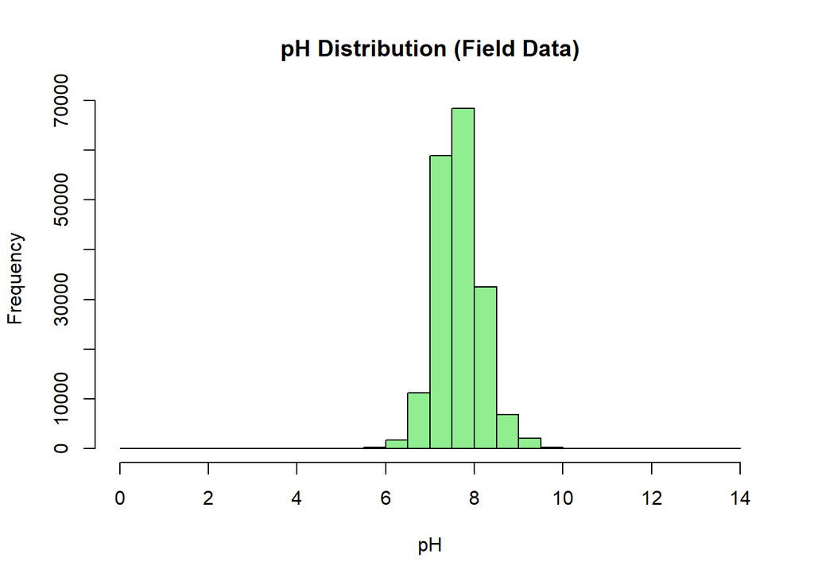

```r
# Histogram for pH (field data)
hist(ph_field_clean$fdr_result, main = "pH Distribution (Field Data)", xlab = "pH", col = "lightgreen", breaks = 30)
```

### Scatter Plot for pH

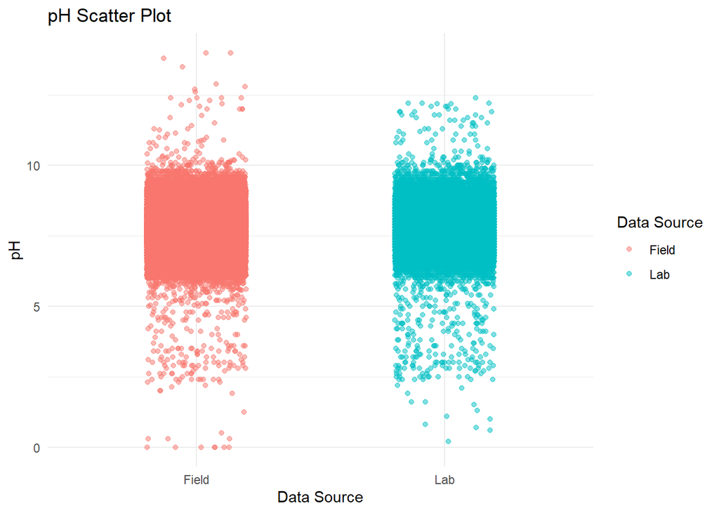

```r
library(ggplot2)
# Combine data for scatter plot
combined_ph_data <- data.frame(
  pH = c(ph_lab_clean$result, ph_field_clean$fdr_result),
  Source = c(rep("Lab", nrow(ph_lab_clean)), rep("Field", nrow(ph_field_clean)))
)

# Scatter plot
ggplot(combined_ph_data, aes(x = Source, y = pH, color = Source)) +
  geom_point(alpha = 0.5, position = position_jitter(width = 0.2)) +
  theme_minimal() +
  labs(title = "pH Scatter Plot",
       x = "Data Source",
       y = "pH",
       color = "Data Source")
```

### Histogram for Hardness (Lab Data)

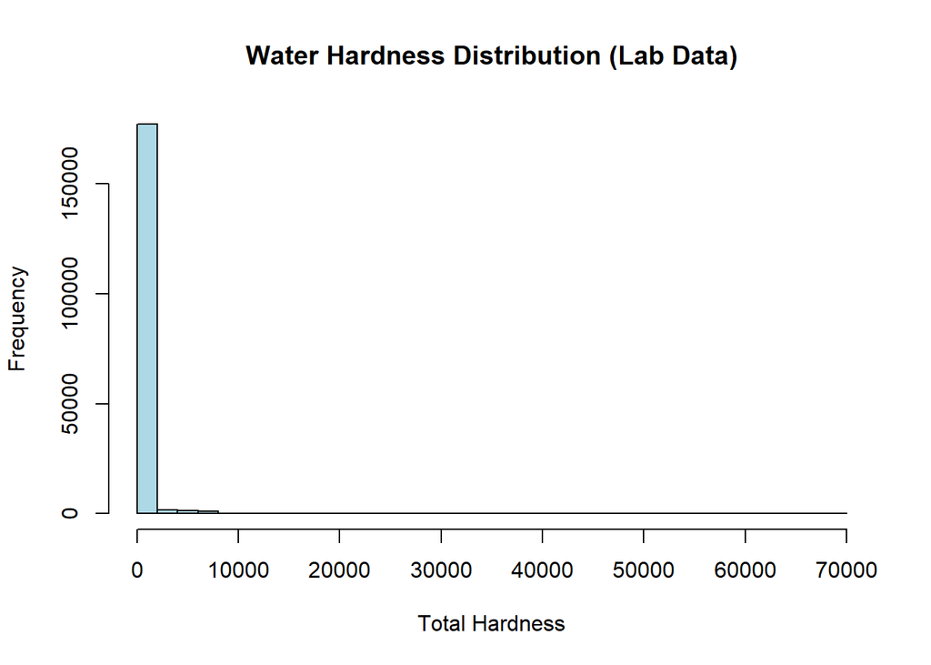

```r
hist(hardness_lab$result, main = "Water Hardness Distribution (Lab Data)", xlab = "Total Hardness", col = "lightblue", breaks = 30)
```

The graph revealed that data needs to be checked for outliers because the boundaries for Total Hardness are: Water hardness is usually measured in milligrams per liter (mg/L) or parts per million (ppm). Soft water: 0-60 mg/L, Moderately hard water: 61-120 mg/L, Hard water: 121-180 mg/L, Very hard water: >180 mg/L.

```r
# Unique units for Total Hardness
unique_units <- unique(hardness_lab$units)
cat("Unique units for Total Hardness:\n")
```

```
## Unique units for Total Hardness:
```

```r
print(unique_units)
```

```
## [1] "mg/L as CaCO3" "mg/L"
```

```r
# Statistical data for Total Hardness
summary(hardness_lab$result)
```

```
##    Min. 1st Qu.  Median    Mean 3rd Qu.    Max.
##     1.0    79.0   167.0   344.9   336.0 69844.0
```

Very large values were found. Filtering: Remove values that exceed a reasonable range (e.g., >1000 mg/L).

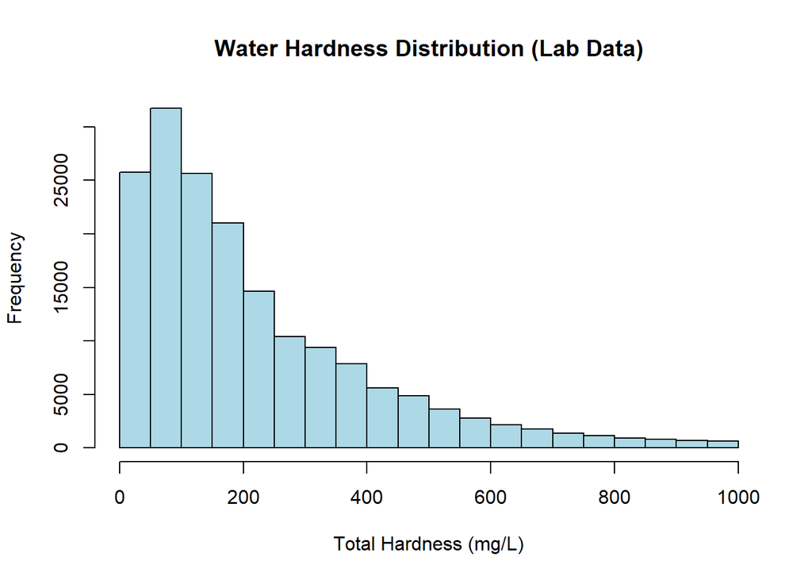

```r
# Filtering anomalous Total Hardness values
hardness_lab_clean <- hardness_lab %>% filter(result >= 0 & result <= 1000)

# Histogram for Total Hardness (lab data)
hist(hardness_lab_clean$result, main = "Water Hardness Distribution (Lab Data)", xlab = "Total Hardness (mg/L)", col = "lightblue", breaks = 30)
```

### Histogram for Conductance (Field Data)

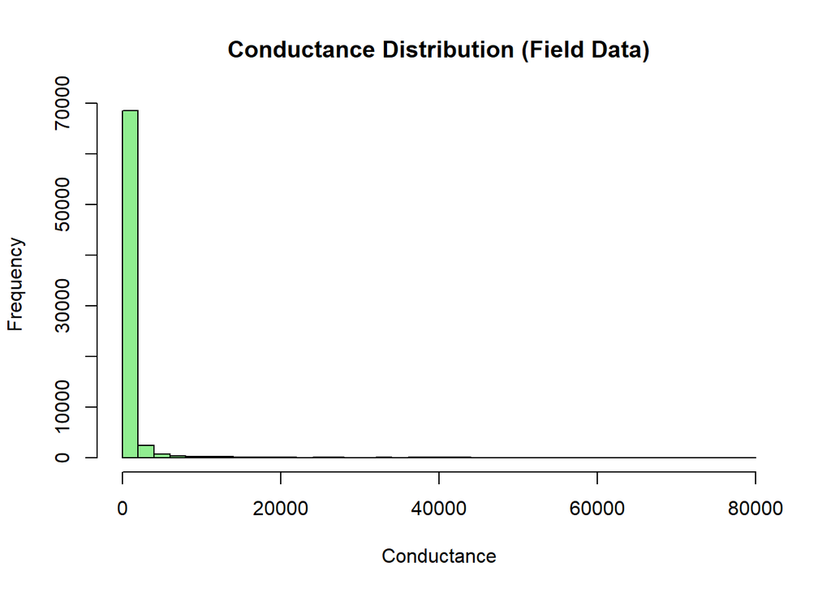

```r
hist(hardness_field$fdr_result, main = "Conductance Distribution (Field Data)", xlab = "Conductance", col = "lightgreen", breaks = 30)
```

The graph revealed that data needs to be checked for outliers because the boundaries are: Conductivity is usually measured in microsiemens per centimeter (µS/cm). Freshwater: < 1500 µS/cm, Moderately saline water: 1500-5000 µS/cm, Saline water: > 5000 µS/cm.

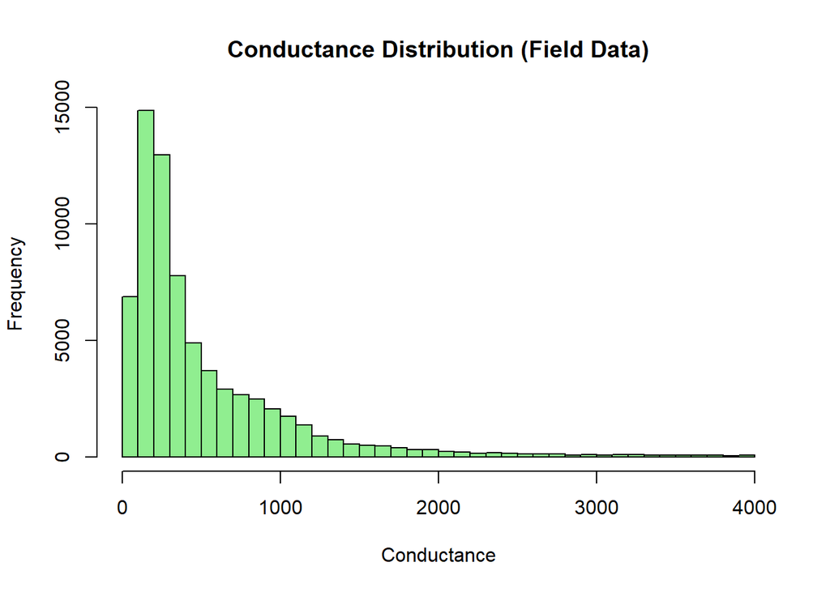

```r
# Filtering anomalous Conductance values
conductance_field_clean <- hardness_field %>% filter(fdr_result >= 0 & fdr_result <= 4000)

# Histogram for Conductance (field data)
hist(conductance_field_clean$fdr_result, main = "Conductance Distribution (Field Data)", xlab = "Conductance", col = "lightgreen", breaks = 30)
```

# Study of water of North California

Approximate Coordinates for Northern California Latitude: from 38.0 to 42.0 Longitude: from -124.5 to -120.0

Filter Data by Coordinates, Analyze pH Level Changes Over Time:

Use the sampling date data to analyze temporal changes.

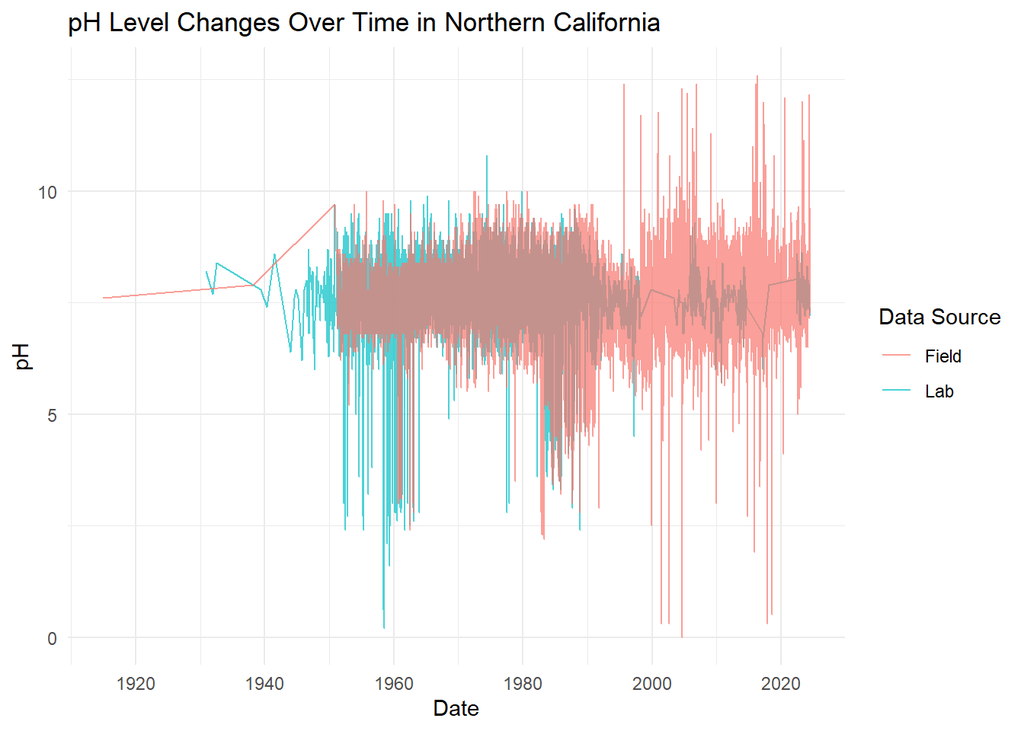

```r
library(dplyr)
library(ggplot2)
library(lubridate)
# Filter stations in Northern California
north_california_stations <- stations_clean %>%
  filter(latitude >= 38.0 & latitude <= 42.0,
         longitude >= -124.5 & longitude <= -120.0)

# Get station_id for Northern California
north_california_station_ids <- north_california_stations$station_id

# Filter pH data for Northern California
ph_north_cal_lab <- ph_lab_clean %>% filter(station_id %in% north_california_station_ids)
ph_north_cal_field <- ph_field_clean %>% filter(station_id %in% north_california_station_ids)

# Combine data and convert date
ph_north_cal_lab$sample_date <- as.Date(ph_north_cal_lab$sample_date)
ph_north_cal_field$sample_date <- as.Date(ph_north_cal_field$sample_date)

# Plot pH level changes over time
ggplot() +
  geom_line(data = ph_north_cal_lab, aes(x = sample_date, y = result, color = "Lab"), alpha = 0.7) +
  geom_line(data = ph_north_cal_field, aes(x = sample_date, y = fdr_result, color = "Field"), alpha = 0.7) +
  theme_minimal() +
  labs(title = "pH Level Changes Over Time in Northern California",
       x = "Date",
       y = "pH",
       color = "Data Source")
```

On the graph, observed that data is available from 1915, but there are very few records, so I can filter out data before 1940.

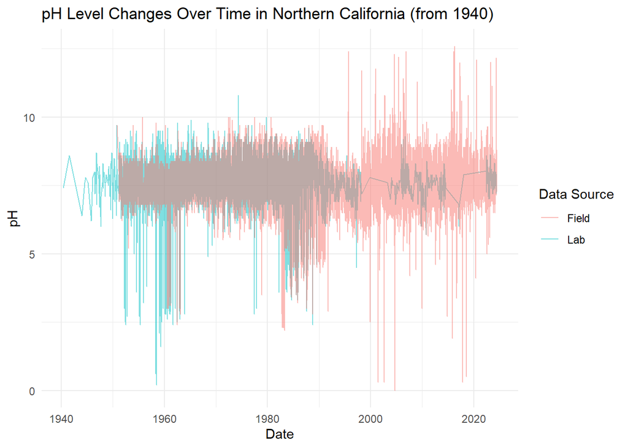

```r
# Filter data from 1940 onwards
ph_north_cal_lab <- ph_north_cal_lab %>% filter(sample_date >= as.Date("1940-01-01"))
ph_north_cal_field <- ph_north_cal_field %>% filter(sample_date >= as.Date("1940-01-01"))

# Plot pH level changes over time
ggplot() +
  geom_line(data = ph_north_cal_lab, aes(x = sample_date, y = result, color = "Lab"), alpha = 0.5) +
  geom_line(data = ph_north_cal_field, aes(x = sample_date, y = fdr_result, color = "Field"), alpha = 0.5) +
  theme_minimal() +
  labs(title = "pH Level Changes Over Time in Northern California (from 1940)",
       x = "Date",
       y = "pH",
       color = "Data Source")
```

#### Сreate separate plots for groundwater and surface water sources by filtering the data based on station_type.

```r
# Unique station types in lab_results_clean
unique_station_types_lab <- unique(lab_results_clean$station_type)
cat("Unique station types in lab_results_clean:\n")
```

```
## Unique station types in lab_results_clean:
```

```r
print(unique_station_types_lab)
```

```
## [1] Groundwater   Surface Water Other
## Levels: Groundwater Other Surface Water
```

```r
# Unique station types in field_results_clean
unique_station_types_field <- unique(field_results_clean$station_type)
cat("\nUnique station types in field_results_clean:\n")
```

```
##
## Unique station types in field_results_clean:
```

```r
print(unique_station_types_field)
```

```
## [1] Surface Water Groundwater   Other
## Levels: Groundwater Other Surface Water
```

```r
# Filtering groundwater sources
ph_groundwater_lab <- ph_north_cal_lab %>% filter(station_type == "Groundwater")
ph_groundwater_field <- ph_north_cal_field %>% filter(station_type == "Groundwater")

# Filtering surface water sources
ph_surfacewater_lab <- ph_north_cal_lab %>% filter(station_type == "Surface Water")
ph_surfacewater_field <- ph_north_cal_field %>% filter(station_type == "Surface Water")
```

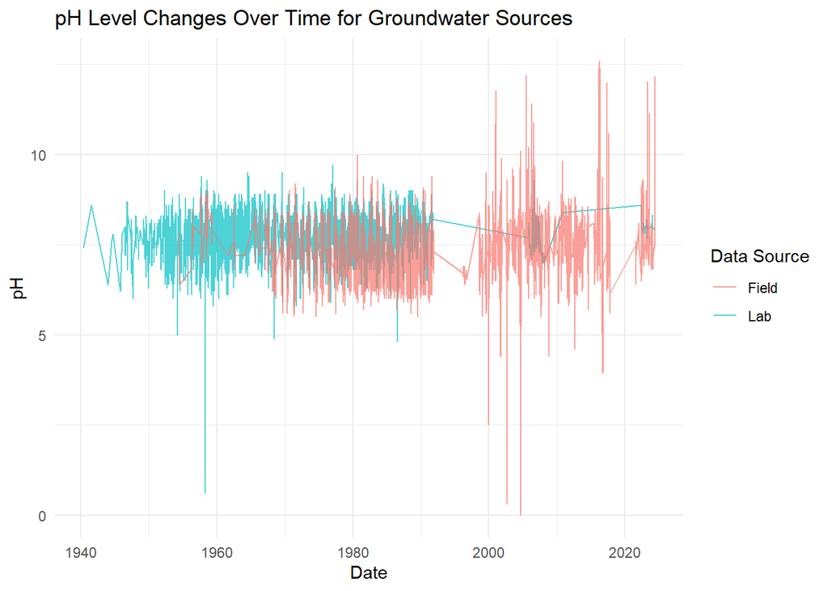

```r
# Plot for groundwater sources
ggplot() +
  geom_line(data = ph_groundwater_lab, aes(x = sample_date, y = result, color = "Lab"), alpha = 0.7) +
  geom_line(data = ph_groundwater_field, aes(x = sample_date, y = fdr_result, color = "Field"), alpha = 0.7) +
  theme_minimal() +
  labs(title = "pH Level Changes Over Time for Groundwater Sources",
       x = "Date",
       y = "pH",
       color = "Data Source")
```

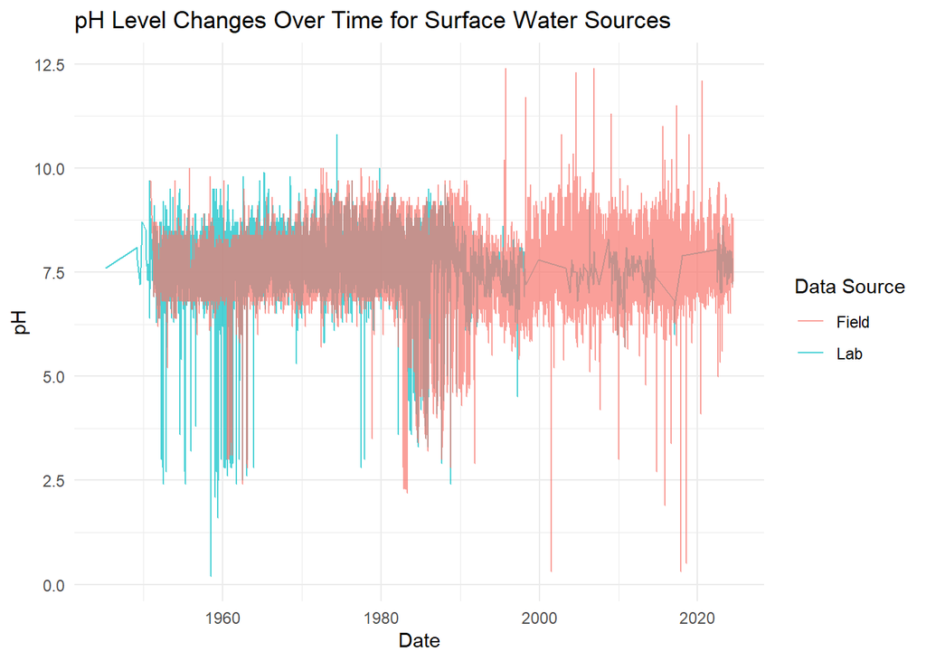

```r
# Plot for surface water sources
ggplot() +
  geom_line(data = ph_surfacewater_lab, aes(x = sample_date, y = result, color = "Lab"), alpha = 0.7) +
  geom_line(data = ph_surfacewater_field, aes(x = sample_date, y = fdr_result, color = "Field"), alpha = 0.7) +
  theme_minimal() +
  labs(title = "pH Level Changes Over Time for Surface Water Sources",
       x = "Date",
       y = "pH",
       color = "Data Source")
```

By the end of the last century, after 1995, it is visible on the graph that surface water sources sharply reduced water research in laboratory conditions, and then in some years until 2005, it was almost zero, and water quality monitoring was only carried out in field conditions. From 2005 to 2015, there is a small stage of laboratory research, and then observations are almost absent again until 2021.

## Investigating water in Northern California by hardness parameters.

I decided to take a more specific region of Northern California, namely the one where I live - Placer. For the study of hardness, I will use only laboratory research.

```r
library(leaflet)
```

```r
library(dplyr)

# Filtering data by laboratory analysis
hardness_lab <- lab_results_clean %>% filter(parameter == "Total Hardness")

# Filtering data by geographic coordinates
placer_county_data <- stations_clean %>%
  filter(latitude >= 38.7542 & latitude <= 39.3122,
         longitude >= -121.5047 & longitude <= -120.0260)

# Getting station_id for Placer County
placer_county_station_ids <- placer_county_data$station_id

# Filtering hardness data for Placer County
hardness_placer_lab <- hardness_lab %>% filter(station_id %in% placer_county_station_ids)

# Number of rows in hardness_placer_lab
nrow(hardness_placer_lab)
```

```
## [1] 1916
```

```r
# Filtering data by geographic coordinates
placer_county_data <- stations_clean %>%
  filter(latitude >= 38.7542 & latitude <= 39.3122,
         longitude >= -121.5047 & longitude <= -120.0260)

# Getting station_id for Placer County
placer_county_station_ids <- placer_county_data$station_id

# Filtering hardness data for Placer County
hardness_placer_lab <- hardness_lab %>% filter(station_id %in% placer_county_station_ids)

# Separating into groundwater and surface water sources
placer_county_groundwater <- placer_county_data %>% filter(station_type == "Groundwater")
placer_county_surfacewater <- placer_county_data %>% filter(station_type == "Surface Water")

# Creating a map
leaflet(data = placer_county_data) %>%
  addTiles() %>%
  addCircleMarkers(data = placer_county_groundwater, ~longitude, ~latitude,
                   radius = 5,
                   fillOpacity = 0.5,
                   color = "blue",
                   popup = ~paste("Station ID:", station_id, "\n", "Station Name:", station_name)) %>%
  addCircleMarkers(data = placer_county_surfacewater, ~longitude, ~latitude,
                   radius = 5,
                   fillOpacity = 0.5,
                   color = "red",
                   popup = ~paste("Station ID:", station_id, "\n", "Station Name:", station_name)) %>%
  addLegend("bottomright", colors = c("blue", "red"), labels = c("Groundwater", "Surface Water"), title = "Legend")
```

[interactive chart not shown]

```r
# Filtering data by geographic coordinates and source type
placer_county_surfacewater <- stations_clean %>%
  filter(latitude >= 38.7542 & latitude <= 39.3122,
         longitude >= -121.5047 & longitude <= -120.0260,
         station_type == "Surface Water")

# Getting station_id for surface water sources
placer_county_surfacewater_station_ids <- placer_county_surfacewater$station_id

# Filtering hardness data for surface water sources
hardness_placer_surfacewater <- hardness_lab %>% filter(station_id %in% placer_county_surfacewater_station_ids)

# Determining water hardness category
hardness_placer_surfacewater$hardness_category <- ifelse(hardness_placer_surfacewater$result < 60, "Soft",
                                                        ifelse(hardness_placer_surfacewater$result < 120, "Moderately Hard",
                                                               ifelse(hardness_placer_surfacewater$result < 180, "Hard", "Very Hard")))

# Creating a map
leaflet(data = hardness_placer_surfacewater) %>%
  addTiles() %>%
  addCircleMarkers(~longitude, ~latitude,
                   radius = 5,
                   fillOpacity = 0.5,
                   color = ~ifelse(hardness_category == "Soft", "blue",
                                    ifelse(hardness_category == "Moderately Hard", "green",
                                           ifelse(hardness_category == "Hard", "yellow", "red"))),
                   popup = ~paste("Station ID:", station_id, "\n", "Station Name:", station_name, "\n", "Hardness:", result, "\n", "Category:", hardness_category)) %>%
  addLegend("bottomright", colors = c("blue", "green", "yellow", "red"), labels = c("Soft", "Moderately Hard", "Hard", "Very Hard"), title = "Legend") %>%
  addControl("Surface Water Hardness Levels in Placer County", position = "topright")
```

[interactive chart not shown]

As a rule, water from surface sources should not have high total dissolved solids and should not be hard or very hard. Therefore, the yellow dots on the map should be studied in more detail, especially those that are located on small streams in agricultural areas.

```r
library(leaflet)
library(dplyr)

# Filtering data by geographic coordinates and source type
placer_county_groundwater <- stations_clean %>%
  filter(latitude >= 38.7542 & latitude <= 39.3122,
         longitude >= -121.5047 & longitude <= -120.0260,
         station_type == "Groundwater")

# Getting station_id for groundwater sources
placer_county_groundwater_station_ids <- placer_county_groundwater$station_id

# Filtering hardness data for groundwater sources
hardness_placer_groundwater <- hardness_lab %>% filter(station_id %in% placer_county_groundwater_station_ids)

# Determining water hardness category
hardness_placer_groundwater$hardness_category <- ifelse(hardness_placer_groundwater$result < 60, "Soft",
                                                        ifelse(hardness_placer_groundwater$result < 120, "Moderately Hard",
                                                               ifelse(hardness_placer_groundwater$result < 180, "Hard", "Very Hard")))

# Creating a map
leaflet(data = hardness_placer_groundwater) %>%
  addTiles() %>%
  addCircleMarkers(~longitude, ~latitude,
                   radius = 5,
                   fillOpacity = 0.5,
                   color = ~ifelse(hardness_category == "Soft", "blue",
                                    ifelse(hardness_category == "Moderately Hard", "green",
                                           ifelse(hardness_category == "Hard", "yellow", "red"))),
                   popup = ~paste("Station ID:", station_id, "\n", "Station Name:", station_name, "\n", "Hardness:", result, "\n", "Category:", hardness_category)) %>%
  addLegend("bottomright", colors = c("blue", "green", "yellow", "red"), labels = c("Soft", "Moderately Hard", "Hard", "Very Hard"), title = "Legend") %>%
  addControl("Groundwater Hardness Levels in Placer County", position = "topright")
```

[interactive chart not shown]

```r
# Filtering data by geographic coordinates and source type
placer_county_groundwater <- stations_clean %>%
  filter(latitude >= 38.7542 & latitude <= 39.3122,
         longitude >= -121.5047 & longitude <= -120.0260,
         station_type == "Groundwater")

# Getting station_id for groundwater sources
placer_county_groundwater_station_ids <- placer_county_groundwater$station_id

# Filtering hardness data for groundwater sources
hardness_placer_groundwater <- hardness_lab %>% filter(station_id %in% placer_county_groundwater_station_ids)

# Determining water hardness category
hardness_placer_groundwater$hardness_category <- ifelse(hardness_placer_groundwater$result < 60, "Soft",
                                                        ifelse(hardness_placer_groundwater$result < 120, "Moderately Hard",
                                                               ifelse(hardness_placer_groundwater$result < 180, "Hard", "Very Hard")))

# Selecting stations with high hardness (red dots)
high_hardness_stations <- hardness_placer_groundwater %>% filter(hardness_category == "Very Hard")

# Creating a table
high_hardness_stations_table <- data.frame(
  Station_Name = high_hardness_stations$station_name,
  County_Name = high_hardness_stations$county_name
)

# Printing the table
print(high_hardness_stations_table)
```

```
##     Station_Name County_Name
## 1  12N06E17G001M      Placer
## 2  12N07E07P001M      Placer
## 3  13N05E24P001M      Placer
## 4  11N04E02M002M      Sutter
## 5  12N04E25N001M      Sutter
## 6  12N04E25N001M      Sutter
## 7  13N04E14R003M      Sutter
## 8  13N04E35J002M      Sutter
## 9  13N05E07Q002M      Sutter
## 10 13N05E07Q002M      Sutter
## 11 13N05E07Q002M      Sutter
## 12 13N05E07Q002M      Sutter
## 13 13N04E12H004M        Yuba
## 14 13N04E12H004M        Yuba
## 15 13N04E12H004M        Yuba
## 16 13N04E12H004M        Yuba
## 17 13N04E12H004M        Yuba
## 18 14N05E16P001M        Yuba
## 19 14N05E16Q001M        Yuba
## 20 14N05E16Q001M        Yuba
## 21 14N05E16Q001M        Yuba
## 22 14N05E16Q001M        Yuba
## 23 14N05E21Q001M        Yuba
## 24 14N05E21Q001M        Yuba
## 25 14N05E21Q001M        Yuba
## 26 14N05E21Q001M        Yuba
## 27 14N05E21Q001M        Yuba
## 28 15N04E24E001M        Yuba
## 29 17N05E26J001M        Yuba
```